# Assignment 1: Getting Started in R

### Assignment 1 Objectives

> The purpose of this first assignment is to demonstrate that you have downloaded the “base R” and “RStudio” statistical programs and can open a SPSS datafile in RStudio.

This document was created as an R Markdown file. You will learn about R Markdown files later in the assignment. First, I want to familiarize you with the RStudio interface.

#### **By the end of assignment #1, you should…**

- have created folders on both your personal computer and in cloud storage
- have 6 *full* datasets downloaded
- know how to create R Markdown (RMD) document in RStudio
- know how to add and modify text, including *italic* or **bold** font and level headings, in an R Markdown document
- know how to add and use an R code chunk in an RMD file
- know how to use `install.packages()` and `library()` commands to install and load packages in R
- know how to add hashtags (“#”) to comment out a section of R code so it does not run
- be able to use the “here” package and `here()` function for simple, reproducible file directory referencing
- be able to read data into R/RStudio using `read_spss()` function from “haven” package, then assign it to an object in the R environment using an assignment (`<-`) operator
- be able to knit your RMD file into a Word document that you can save and submit for course credit

### Assumptions & Ground Rules

For all assignments in this class, you must have access to a computer and Microsoft Word. As a TAMUSA student you have access to the Microsoft 365 suite, which includes 1TB of storage on OneDrive. You may find instructions for how to access and install programs (such as Microsoft Word) from Microsoft 365 in the **Resources & Supplemental Texts** folder under the Course Content tab in Blackboard.

For this and all future assignments, I will assume you are working on your own computer and are downloading base R and RStudio (free open source) programs on your own computer. If you experience technical difficulties, remember that you can call ITS at 210-784-4357 or email them at helpdesk@tamusa.edu for help.

*Also, for this and all future assignments, you MUST type all commands in by hand. Do not copy & paste except for troubleshooting purposes (i.e., if you cannot figure out what you mistyped).*

Early on, you may have a lot of trouble getting your code to run due to minor typos. This is normal. Remember, you are learning to read and write a new (coding) language. As with learning any new languages, we learn from practice - and from correcting our mistakes.

### Part 1 (Assignment 1.1)

> **Goal:** Create new CRIM5305_L_LastName folder on your local computer, then download datasets and save to your new folder (i.e., “L” for “local” computer folder).

*(**Note:*** *When following instructions, always substitute “LastName” for your own last name! Also, substitute YEAR-MO-DY for the actual date. E.g., **2023-01-27_Ducate_CRIM5305_Assign01**)*

1. On your computer, create a new folder called `CRIM5305_L_LastName` in a location that is easy to access (e.g., on Desktop or in “My Documents”).
2. Create a new folder in your CRIM5305_L folder called `Datasets` (CRIM5305_L_LastName > Datasets)
3. Visit the Companion Website [here](https://edge.sagepub.com/bachmansccj5e/student-resources/datasets) for Bachman, Paternoster, and Wilson’s *Statistics for Criminology & Criminal Justice, 5th Ed* (specifically, under the heading: **R Data Sets, Full Versions**) for the datasets.
   1. Under the header **Data Sets for SPSS Full Version**, you will see six datasets:
      - Monitoring the Future 2013 grade 10_0.sav
      - NCVS lone offender assaults 1992 to 2013.sav
      - Youth_0.sav
      - 2012 States Data.sav
      - 2013 YRBS.sav
      - GSS 2014.sav
4. Download each dataset and save them all in the new “CRIM5305_L_LastName > Datasets” folder you made in Part 2.
   - **NOTE**: To download, you may need to right click and select “Save link as…”
   - Do NOT try to open the datasets after you have downloaded them. If your computer asks which program to open them with, press CANCEL. Do not open them in Microsoft Word. Simply download them. We will open them in RStudio in Part 4.
5. **Take a screenshot (#1)** of your new CRIM5305_L_LastName > Datasets folder with all six datasets downloaded in it.
   - *PC (Option 1): ctrl + prt sc then ctrl + P into a Word document.*
   - *PC (Option 2)*: In the search bar type in “snipping tool” and use the tool to take a snapshot of your Datasets folder.
   - *Mac (Option 1):* Command + shift + 3; this takes a screenshot of your entire screen and saves on your desktop.
   - *Mac (Option 2):* Command + shift + 4; this allows you to click and drag to select which part of your desktop you want to screenshot; this also saves on your desktop.
6. Insert the screenshot into a Word document to your `CRIM5305_L_LastName` folder. Name the file: **YEAR-MO-DY_LastName_CRIM5305_Assign01_folder-screenshot**
7. (Optional) Create a folder titled `CRIM5305_C_LastName` in your cloud storage (e.g., iCloud, Dropbox, OneDrive).
   - If you have your cloud storage synced to your computer, you can work out of this folder instead of your `CRIM5305_L_LastName` folder.
   - If you choose to work out of this folder instead of your local folder (which I recommend), be sure to copy your `Datasets` folder into this folder as well.

### Part 2 (Assignment 1.2)

> **Goal:** Download R & R Studio; Open R Markdown; Knit first RMD file

In this section, you will begin by downloading and installing two programs on your computer: base R and RStudio.The first program, R, is simultaneously a computer coding language and a statistical software program. The second, RStudio, is an integrated development environment (IDE) that provides a more user-friendly interface for working with the R program. Throughout this course, you will learn to write and submit R code in RStudio to run statistical commands in the R program. After installing R & RStudio, you will run some simple commands to familiarize yourself with the basic features of the program and install two R packages.

1. Follow the instructions at the link below to install the latest versions of R and RStudio on your personal Windows or Mac computer: https://www.datacamp.com/community/tutorials/installing-R-windows-mac-ubuntu. For more detailed instructions, check out Danielle Navarro’s videos for installing R and R Studio in [Windows](https://www.youtube.com/watch?v=KAeHFzxbHTA) or on a [Mac](https://www.youtube.com/watch?v=ay25o485YXs).
2. Visit Antoine Soetewey’s blog (*AS blog*) entry at the link below, read the section titled “Main Components of RStudio,” and follow along in RStudio on your computer: https://towardsdatascience.com/how-to-install-r-and-rstudio-584eeefb1a41
3. Once you have installed RStudio, open it.
4. In RStudio, open an “R Markdown” file (File > New File > R Markdown…).
   1. *Note:* *An R Script, which is the default file in RStudio, allows us to write and run code within R. However, an R Markdown file does this as well, while also permitting us to do so much more. For instance, you can write and edit text, write and run R code, and generate statistical results and plots directly in the RMarkdown file. You can even create entire books and webpages using R Markdown. In fact, this assignment was created using R Markdown!*
   2. R Markdown is an essential tool for producing reproducible research because, with it, we can thoroughly document and simultaneously provide detailed explanations for all of our coding decisions in a project - from opening and manipulating data, to recoding and combining variables, to summarizing and analyzing data, to creating and modifying figures.
   3. We will start by simply opening and saving a new R Markdown file. For more detailed instructions, check out Danielle Navarro’s [video](https://www.youtube.com/watch?v=IkRXHcNNk90) on creating a new R Markdown file.

[figure not shown]

Opening a new R Markdown file

4. The dialogue box asks for a **Title**, an **Author**, and a **Default Output Format** for your new R Markdown file.
   1. In the **Title** box, enter *CRIM5305 Assignment 1*.
   2. In the **Author** box, enter your First and Last Name (e.g., *Caitlin Ducate*).
   3. Under **Default Output Format** box, select “Word document” (HTML is usually the default selection)
      - *(***Note:** *You must have Microsoft Word installed for this to work properly. TAMUSA students can install Microsoft word [and the whole Microsoft 365 suite] for free.)*
   4. Click `OK` to create your new R Markdown file. It should look like this:

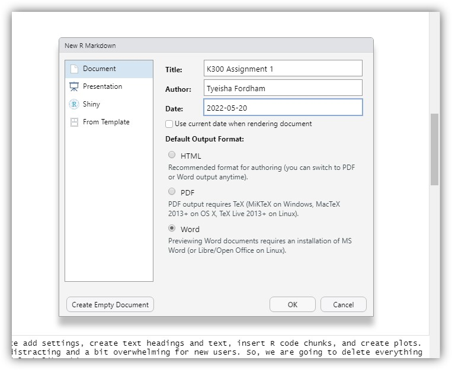

5. The new R Markdown file contains a simple pre-populated template to show users how to do basic tasks like add settings, create text headings and text, insert R code chunks, and create plots. Feel free to read through the template - you may find it helpful. Personally, I find the template a little distracting and a bit overwhelming for new users. So, we are going to delete everything after the metadata and second set of three dashes (i.e., after the YAML header). Your R Markdown file should look like this:

[figure not shown]

Keep the YAML header; delete the template

6. Familiarize yourself with R Markdown by adding some headers, text, and R code chunk.
   1. Hit `<Enter>` on your keyboard to leave a blank line between the header and the first line of text.
   2. On the next line (line 8), type: ## Part 1 (Assignment 1.1)
      - In the markdown document, two hashmarks specifies a second-level text heading. Be sure to include a space after the last hashmark.
      - *Note:* *This is different from a R Script file, which only contains R code. A hashmark transforms code into a comment that is not evaluated or run in an R Script file (and in an R code chunk in R Markdown, which you will learn about below).*
   3. Hit `<Enter>` and, on the next line (line 9), type: ### Learning R Markdown
      - Three hashmarks specifies a third-level text heading.
   4. Hit `<Enter>` to leave another blank line (line 10)
   5. On the next line (line 11), type the following sentence: This R Markdown document contains *my work* for Assignment 2. It is **my work** and *only* my work.
      - To *italicize*, place a single asterisk (*) before and after the word or text segment.
      - To **bold**, place two asterisks (**) before and after the word or text segment.
      - To *bold and italicize*, place three asterisks (***) before and after the word or text segment.
      - There are a lot of sources online that explain various formatting options in R Markdown. For examples, check out [here](https://r4ds.had.co.nz/r-markdown.html), [here](https://rmarkdown.rstudio.com/authoring_basics.html), [here](https://www.rstudio.com/wp-content/uploads/2015/03/rmarkdown-reference.pdf), [here](http://rstudio-pubs-static.s3.amazonaws.com/520444_e7781b1adde6415dbf857b9969ea5eed.html), and [here](https://ntaback.github.io/UofT_STA130/Rmarkdownforclassreports.html). Also, check out Nicholas Tierney’s bookdown for descri ptions of and solutions to [common problems with RMarkdown](https://rmd4sci.njtierney.com/common-problems-with-rmarkdown-and-some-solutions.html).
7. Before typing anything else, save your new R Markdown file as: **YEAR-MO-DY_LastName_CRIM5305_Assign01**. Your RStudio session should now look similar to this:

[figure not shown]

Your first R Markdown file

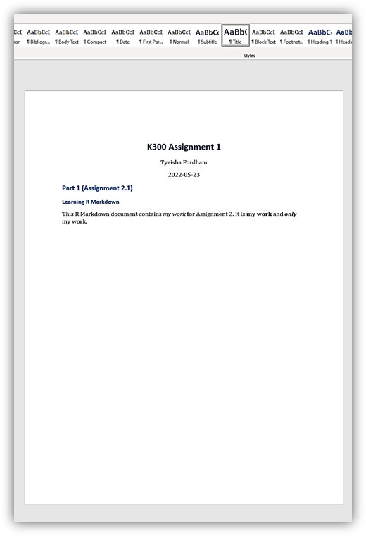

9. Now, in R Markdown, you are ready to insert a code chunk and begin reading in and assigning your data to an object in R!

### Part 3 (Assignment 1.3)

> **Goal:** Insert R code chunk in R Markdown; Install `haven` (with `tidyverse`) and `here` packages then load in R
1. Create a second-level header in R Markdown (hereafter, “RMD”) file titled: “Load Libraries”
2. Insert an R code chunk
1. Click “Code > Insert chunk” or click the “Insert code chunk” button (green box with a “C” in it) and select “R” option (see below).
2. Type `install.packages("tidyverse")` into the code chunk and hit the right-pointing green arrow on the right side of the chunk.
   - You can also highlight the text with your cursor, hit RUN, or hit (Windows: CTRL + Enter; Mac: cmd + Enter). The [*AS blog*](https://medium.com/towards-data-science/getting-started-in-r-markdown-2d3de636bde3) referenced above gives brief directions on installing packages and operating RMD. For more detailed instructions on installing packages, see Danielle Navarro’s [video](https://www.youtube.com/watch?v=kpHZVyDvEhQ&list=PLRPB0ZzEYegOZivdelOuEn-R-XUN-DOjd&index=4) on the topic.

[figure not shown]

Insert R code chunk

[figure not shown]

Insert R code chunk

3. Once installed, load the `haven` package by typing, selecting, and running the command `library("haven")` in your RMD file.
   - For more information about the haven package, see: https://cran.r-project.org/web/packages/haven/readme/README.html
   - **Note:** The `haven` package is part of a much larger suite of packages known as the `tidyverse`, which you have just installed.
4. Now, repeat the process above to install the `here` package.
   - Type `install.packages("here")` into your RMD file, hit RUN or select (highlight) this text line, and RUN the selection (Windows: CTRL + Enter; Mac: cmd + Enter).
5. Once installed, load the `here` package by typing, selecting, and running `library("here")` into your RMD file.
   - The `here` package will help you start a replicable project-oriented workflow from the beginning. Here is how it will work once installed:
     - You save your primary RMarkdown code file in your top-level directory folder. For us, that means saving your RMD file in your `CRIM5305_L_LastName` folder.
     - Next, after closing RStudio, you will simply click directly on the RMD file in your `CRIM5305_L_LastName` folder to automatically open it with RStudio. When you do this, your “working directory,” i.e., the place R looks for files by default, will automatically be set to your CRIM5305_L folder.
     - The `here` package will then make it easy to find and call objects (e.g., SPSS dataset) in subfolders of your working directory (e.g., in “Datasets” folder).
6. Check to see if the `haven` and `here` packages loaded properly.
   1. First, find the “Packages” tab (see “blue pane” in [*AS blog*](https://towardsdatascience.com/how-to-install-r-and-rstudio-584eeefb1a41)).
   2. Next, scroll down through the listed packages until you find the haven and here package entries.
   3. If there are checkmarks next to both entries, it worked!

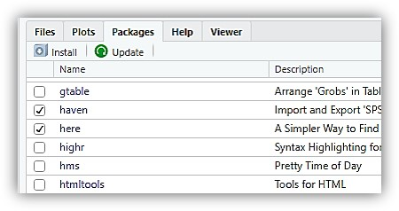

A checkmark means the R package is successfully loaded

### Part 4 (Assignment 1.4)

> **Goal:** Save RMD; Use `haven` package to open SPSS file in RStudio
1. In RStudio, click File > Save As, then save RMD file in CRIM5305_L_LastName folder. You should have already saved and named the file: **YEAR-MO-DY_LastName_CRIM5305_Assign01**

[figure not shown]

Save R Script and Markdown files in top-level folder

[figure not shown]

RStudio session with comments and loaded packages

5. Note the red text in the Console that appeared after loading the `here` package. It confirms the `here` package has set my CRIM5305_L_LastName folder (i.e., for me, CRIM5305_L_Ducate) as the top-level working directory.
4. Open SPSS dataset in RStudio using haven package and assign data to an object in R a.Start a second-level heading titled: “Read in and Assign Data to an Object.” Then, begin a new code chunk and type the following command in your RMD file: `read_spss(here("Datasets","Monitoring the Future 2013 grade 10_0.sav"))`
   - `read_spss()` is a `haven` package command that allows R to read SPSS datafiles
   - Inside the `read_spss()` parentheses, we need to specify the file location and the filename we wish to open, separated by a comma.
   - Instead of specifying the exact path location, we specify `here(“Datasets”,` which uses the here package to locate our “Datasets” folder. By using the here package, your R code should work for anyone on any computer as long as they have the exact same file structure (e.g., you can work from local or cloud storage, or work from different computers)
   - Next, our code specifies the `Monitoring the Future 2013 grade 10_0.sav` file in the “Datasets” folder to open.
     - **Note**: The file name you type in your code must EXACTLY match the name of your data file, including spaces and capital letters.
5. Run the `read_spss()` command. You should see a small snapshot of the data in your R viewer (right-hand side of RStudio,) which looks something like this:

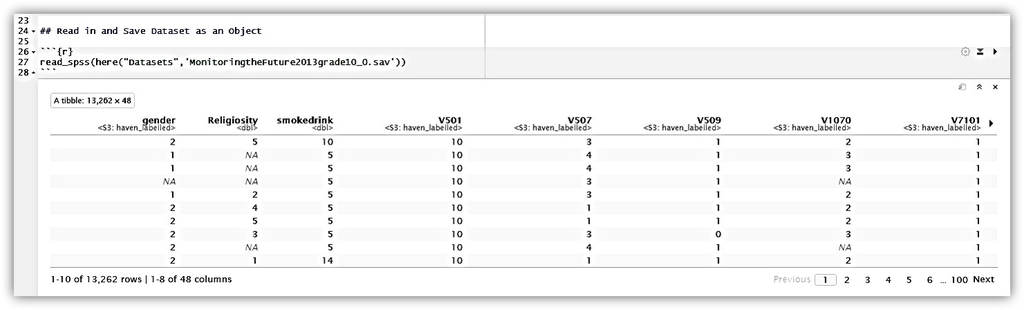

6. You just read a dataset into RStudio!
7. However, you do not want the dataset in the R Console – you want to be able to call the dataset as an object on which you can do things, such as summarize or correlate variables (later). To do this, you need to assign the dataset to an object in the R Environment. Note that your R Environment tab is still empty and looks like this:

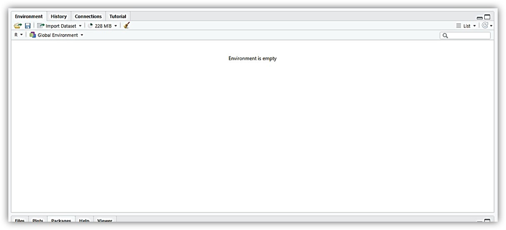

Empty Environment after reading in SPSS data and before creating a data object

8. To assign the dataset to an object in R, type `MF2013g10data <-` *before* the `read_spss()` command.
   - The text `MF2013g10data` is the name we are giving to the data object we are creating.
   - The `<-` command tells R to place whatever follows the text arrow (in this case, the dataset read by the `read_spss()` command) into our `MF2013g10data` object.
     - *Note:* *We can name the object whatever we want (e.g., `mydata`). However, it is good coding practice to be systematic in creating concise yet informative names. The name I selected reminds me that the object is the* **M**onitoring the **F**uture **2013** **g**rade **10** data.
   - Also, R code is *case-specific*, so be careful and consistent with using upper- and lower-case letters!
   - By this point, you may be wondering why I care so much about how you name your folders and files. The short answer is that thoughtful and systematic naming conventions can save you a lot of time and can be very helpful to your future self or to others attempting to reproduce your work. In contrast, *ad hoc* names can cause a great deal of unnecessary frustration. I recommend Danielle Navarro’s videos on [Names machines like](https://www.youtube.com/watch?v=qyO2yikrGug&list=PLRPB0ZzEYegPiBteC2dRn95TX9YefYFyy&index=2) and [Names humans like](https://www.youtube.com/watch?v=vQl8CIU67WU&list=PLRPB0ZzEYegPiBteC2dRn95TX9YefYFyy&index=3) for more information and useful file naming tips.
   - Your RMD code should look like this:

[figure not shown]

Example RMD for reading SPSS Data into R Object

9. Run the line of code in your RMD to create the new data object.

### Part 5

> **Goal:** Submitting your first assignment
1. After completing the first five parts of this assignment, hit ‘Knit’ in the top left (or press ‘Save’ if you selected ‘Knit on Save’). A Word document should pop up with all of your work. It should look like this:

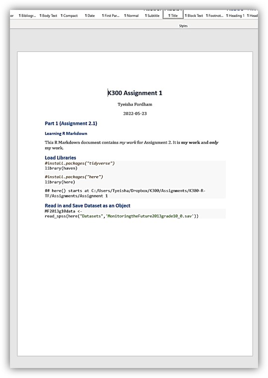

Final Knitted Document for Assignment 1

[figure not shown]

Main Folder after Assignment 1 completion

3. Log into Course Blackboard page, then go to “Course Content > Week 1” and open “Assignment 1.” Follow directions to upload and submit your documents for grading.

### Assignment 1 Objective Checks

**After completing assignment #1, …**

- have you created folders on your personal computer?
- did you download 6 *full* datasets, then save them in your local storage folders?
- do you know how to create a new R Markdown (RMD) document in RStudio?
- do you know how to add and modify text, including *italic* or **bold** font and level headings, in an R Markdown document?
- do you know how to add and use an R code chunk in an RMD file?
- do you know how to use `install.packages()` and `library()` commands to install and load packages in R?
- do you know how to add hashtags (`#`) to comment out a section of R code so it does not run?
- are you able to use the `here` package and `here()` function for simple, reproducible file directory referencing?
- are you able to read data into R/RStudio using `read_spss()` function from “haven” package, then assign it to an object in the R environment using an assignment (`<-`) operator?
- are you able to knit your RMD file into a Word document that you can save and submit for course credit?